# Comparing Management Scenario Model Runs

Nisqually River Case Study

October 22, 2024

## Purpose

The purpose of this document is to create figures that enable direct comparison between management scenario model runs, explanation of differences, and interpretation of what that means for the system. These four management scenarios are just preliminary options to help in the process of developing more realistic management scenarios for each case study.

## Description of the Management Scenarios

In the Nisqually River case study we ran four preliminary scenarios:

#### Base Run

Simulates current dynamics in the Gauntlet.

#### Boat Harvest

Simulates amplified harvest by fishers during fishing operations and normal fishing seasons. Alters values for the steepness and efficiency parameters that describe the relationship between the number of fishers and the number of pinnipeds that are harvested.

#### Zone Exclusion

Simulates removals by managers to attempt to exclude all pinnipeds from the Gauntlet. Assumes that no fisher harvest is occuring simulataneously. Alters the process of removals from boat-based to a “zone” scenario that is governed by an efficiency which describes how many of the pinnipeds at that Gauntlet managers can effectively remove (despite aiming for 100% removal).

#### Haulout Reduction

Simulates removals or disturbance by managers to reduce overall pinnipeds in the source pool. Reduces the total number of pinnipeds by a reduction parameter.

### Parameter Table

The following table summarizes the parameters that were altered to simulate the different management scenarios, or ones that are particularly relevant to specific scenarios.

Parameter Table

|  | Base | Boat | Zone | Haulout |
| --- | --- | --- | --- | --- |
| num_seals | 150 | 150 | 150 | 75 |
| num_zc | 80 | 80 | 80 | 40 |
| num_ej | 10 | 10 | 10 | 5 |
| chin_boats | 14 | 14 | 14 | 14 |
| min_chum_boats | 1 | 1 | 1 | 1 |
| max_chum_boats | 25 | 25 | 25 | 25 |
| zone_efficiency | NA | NA | 0.25 | NA |
| zone_steepness | NA | NA | 10 | NA |
| steepness_H | 200 | 5 | 200 | 200 |
| efficiency | 0.075 | 0.25 | 0.075 | 0.075 |
| scenario | Boat | Boat | Zone | Boat |

## Salmon Response

The total daily salmon presence at the Gauntlet follows two main peaks for the Chinook run and the Chum run. Management scenarios have a significant impact on the total number of salmon at the Gauntlet on each day, though the impact is more noticeable for Chum than Chinook.

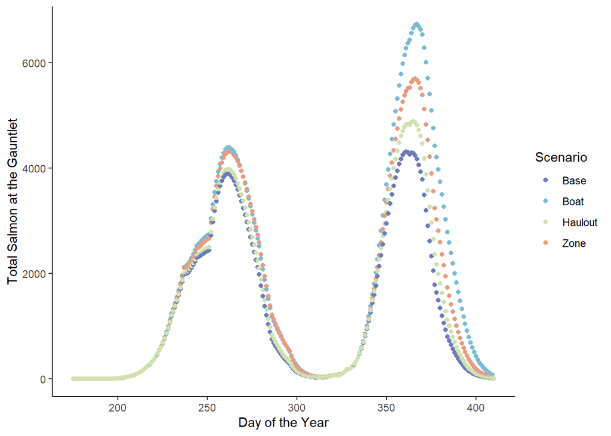

#### Escape

The number of salmon that escape the Gauntlet is dependent on their survival from fishing and predation pressures. The following table describes the escapement for each run under each scenario.

Escapement

|  | Chum | Chinook_GR | Chinook_LN |
| --- | --- | --- | --- |
| Boat | 11005 | 12697 | 498 |
| Zone | 8792 | 12589 | 499 |
| Haulout | 7320 | 11146 | 494 |
| Base | 6294 | 10750 | 492 |

#### Predation

The differences in predation between scenarios also show the largest reduction under the boat-based harvest and zone management scenarios. Predation noticeably spikes as soon as sea lions arrive in the system on the 296th day of the year, heightening the differences between scenarios and emphasizing the impact of California sea lions specifically.

Predated by Pinnipeds

|  | Chum | Chinook_GR | Chinook_LN |
| --- | --- | --- | --- |
| Boat | 8304 | 2138 | 219 |
| Zone | 10656 | 2261 | 219 |
| Haulout | 12227 | 3754 | 224 |
| Base | 13343 | 4168 | 225 |

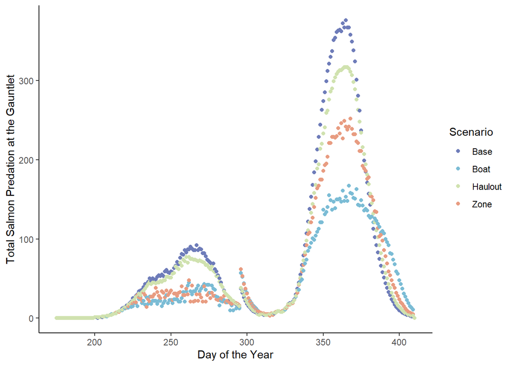

#### Fishery Catch

Fisheries catch is pretty consistent between scenarios. This is built into the structure of the model - catch rates currently do not respond significantly to fish abundance. This assumes no in-season management decisions, changes in fishing opportunities, or changes in escapement goals or quotas. This is not realistic, but meets the goals of the model at this preliminary stage. The total escaped salmon can be used to infer about different management decisions that might be made in the event that the additional “escaped” salmon biomass was detected in the system within season and could be utilized.

Fishery Catch

|  | Chum | Chinook_GR | Chinook_LN |
| --- | --- | --- | --- |
| Boat | 6303 | 4972 | 83 |
| Zone | 6228 | 4958 | 83 |
| Haulout | 6159 | 4918 | 83 |
| Base | 6082 | 4902 | 83 |

## Pinniped Response

#### Harvest Summary

During the Chinook and Coho fisheries, we model a set number of active fishers when fisheries are open since participation seems to be pretty consistent. For the Chum fishery, participation is much less consistent (not all days of the fishery have active fishing effort, and days that do have active fishing effort have a wide range of the number of fishers participating) so we model the number of fishers using a random draw, which results in a much wider spread of participation. When fisheries are not open, there is no fishing activity in the Gauntlet, and therefore no boat-based take. Harbor seals particularly respond to this by increasing their presence and predation impact.

Harvested Pinnipeds

|  | Pv | Zc | Ej |
| --- | --- | --- | --- |
| Boat | 33 | 76 | 6 |
| Zone | 29 | 72 | 2 |
| Base | 0 | 0 | 0 |
| Haulout | 0 | 0 | 0 |

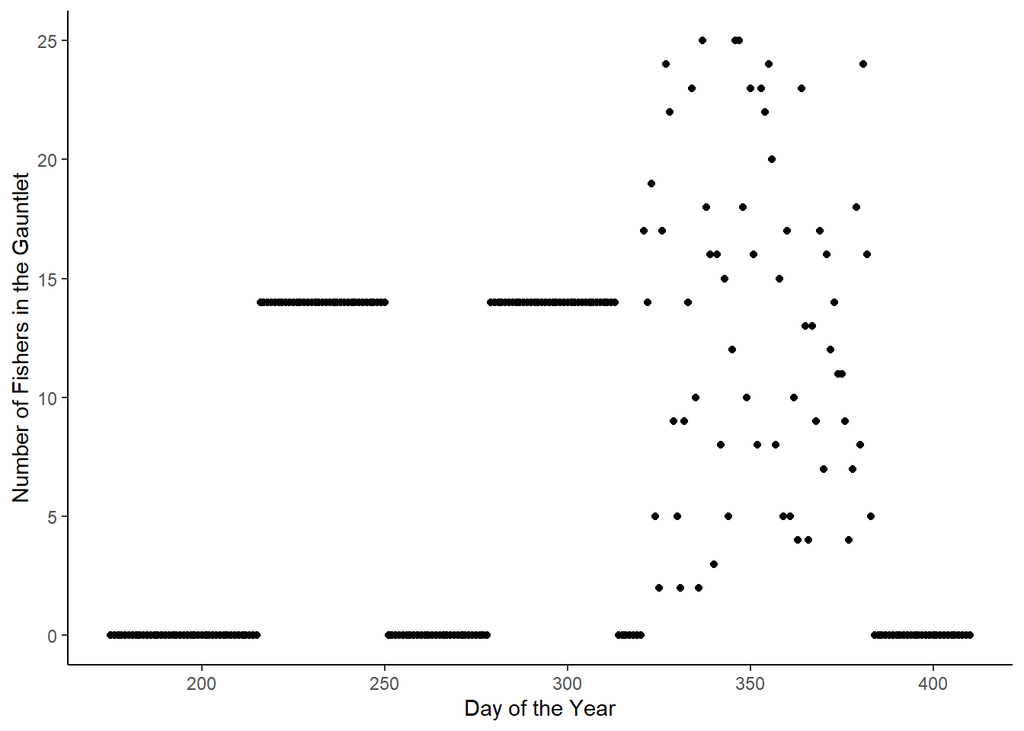

The following plot shows the cumulative number of seals and sea lions that are removed from the Gauntlet over time under each management scenario. In the base and haulout scenarios, no removals happen during the model run within the Gauntlet.

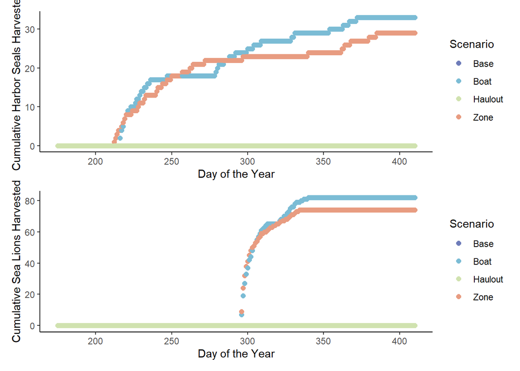

In the boat-based harvest and zone management scenarios, essentially all of the sea lions are removed in a very short period of days, excluding the ones that learn to avoid the Gauntlet fast enough. This may or may not be realistic depending on how efficient fishers and managers are at removing individuals.

#### Pinniped Activity

The following plots describe pinniped presence at the Gauntlet under all four scenarios for each pinniped species separately. You can see that the magnitude of presence differs greatly between scenarios. In the base scenario and haulout reduction scenario, removals aren’t happening in the Gauntlet so pinniped presence closely tracks the timing of each salmon run. In the zone management scenario, pinniped presence is low throughout the model run due to the constant fear conditioning from daily removal activity. In the boat-based harvest scenario, you can see that harbor seal presence closely mirrors the presence of fishers in the Gauntlet, only increasing when fishers are not active.

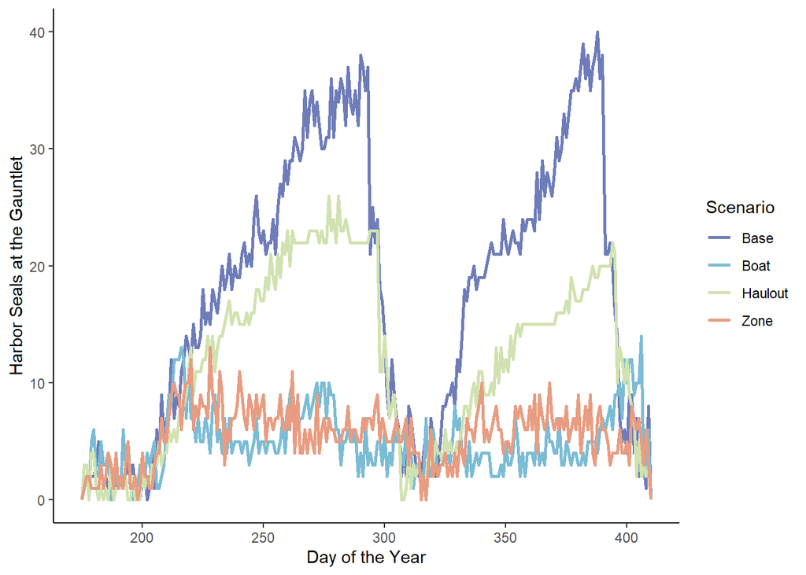

Sea lions arrive at Nisqually on the 296th day of the year. Their presence at the Gauntlet is initially high when they first arrive at the tail end of the Chinook runs, then stays low until the Chum run begins to pick up. Their presence is heavily impacted by the management actions, with much smaller presence under the boat-based harvest or zone management scenarios, and moderate reductions under the haulout scenario. Because sea lions are assumed to be more responsive to the resource availability (Chum salmon), they all act like specialists and are all likely to choose the Gauntlet every day unless deterrent actions are taken or there are insufficient salmon to feed them.

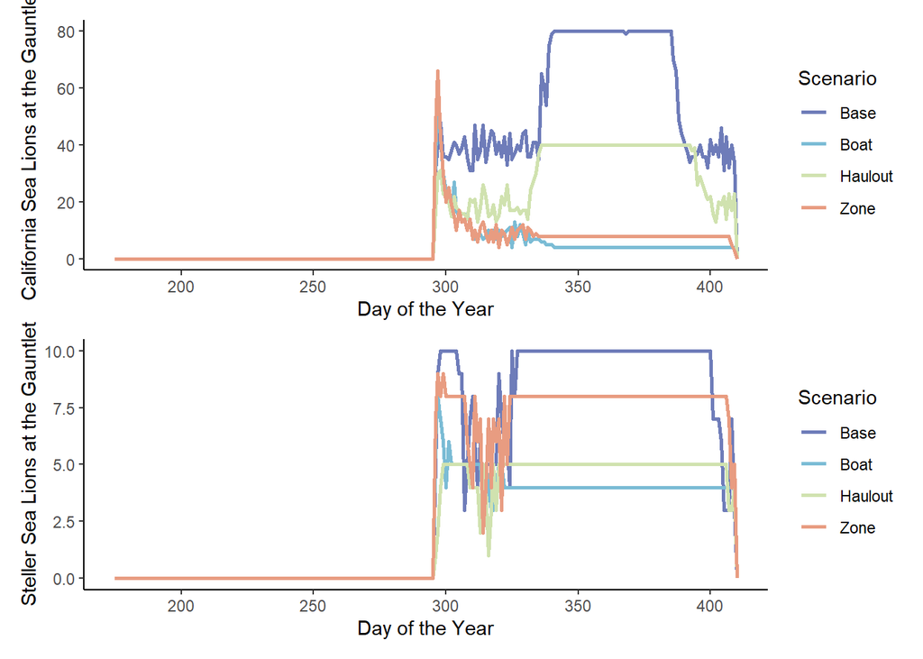

## Conclusion (for now)

Overall it seems like a boat-based harvest would make a lot of sense and possibly have a good positive impact on adult salmon survival and spawning in this system. However, this depends greatly on the parameterization of the scenario, especially our assumptions about the efficiency of pinniped removals by fishers or managers.